# Модуль 1. Классификация почты

```python
import pandas as pd
```

```python
df = pd.read_excel("vigruzka.xlsx")
```

Дропаем `Unnamed` колонки

```python
df = df.drop(columns = ["Unnamed: 8", "Unnamed: 9"], axis = 1)
```

```python
df.head()
```

|  | № п/п | №\nдокумента | Дата\nрегистрации | Исх. №\nДата | Адресат | Краткое\nсодержание | Автор | Компания |
| --- | --- | --- | --- | --- | --- | --- | --- | --- |
| 0 | 1 | WSR/1-838/2019 | 2019-04-09 | 208-409\n08.04.2019 | Уразов Р.Н. | Вх - О возможности использования сетевого изда... | Антонова С.В. | АО «Интерфакс») |
| 1 | 2 | WSR/1-837/2019 | 2019-04-09 | 05-338\n09.04.2019 | Уразов Р.Н. | Вх - Об участии в совещании по вопросу доработ... | Картошкин С.А. | Министерство просвещения Российской Федерации) |
| 2 | 3 | WSR/1-835/2019 | 2019-04-09 | И10-14/3137\n09.04.2019 | Уразов Р.Н. | Вх - О командировании Саликовой К. и Глушко Д.... | Цивилев С.Е. | Администрация Кемеровской области) |
| 3 | 4 | WSR/1-834/2019 | 2019-04-09 | Д2/7121-ИС\n03.04.2019 | Иванюк Л.А. | Вх - Об участии в Чемпионате мира по профессио... | Волков Г.А. | Министерство транспорта Российской Федерации) |
| 4 | 5 | WSR/1-833/2019 | 2019-04-09 | 15-20/06-911\n08.04.2019 | Уразов Р.Н. | Вх - Об участии в церемонии открытия Вузовског... | Атанов И.В. | Ставропольский государственный аграрный универ... |

Определим новые названия для наших колонок

```python
df.columns = ["id", "doc_number", "date", "date_ish", "adresat", "description", "author", "author_company"]
```

```python
df.head()
```

|  | id | doc_number | date | date_ish | adresat | description | author | author_company |
| --- | --- | --- | --- | --- | --- | --- | --- | --- |
| 0 | 1 | WSR/1-838/2019 | 2019-04-09 | 208-409\n08.04.2019 | Уразов Р.Н. | Вх - О возможности использования сетевого изда... | Антонова С.В. | АО «Интерфакс») |
| 1 | 2 | WSR/1-837/2019 | 2019-04-09 | 05-338\n09.04.2019 | Уразов Р.Н. | Вх - Об участии в совещании по вопросу доработ... | Картошкин С.А. | Министерство просвещения Российской Федерации) |
| 2 | 3 | WSR/1-835/2019 | 2019-04-09 | И10-14/3137\n09.04.2019 | Уразов Р.Н. | Вх - О командировании Саликовой К. и Глушко Д.... | Цивилев С.Е. | Администрация Кемеровской области) |
| 3 | 4 | WSR/1-834/2019 | 2019-04-09 | Д2/7121-ИС\n03.04.2019 | Иванюк Л.А. | Вх - Об участии в Чемпионате мира по профессио... | Волков Г.А. | Министерство транспорта Российской Федерации) |
| 4 | 5 | WSR/1-833/2019 | 2019-04-09 | 15-20/06-911\n08.04.2019 | Уразов Р.Н. | Вх - Об участии в церемонии открытия Вузовског... | Атанов И.В. | Ставропольский государственный аграрный универ... |

```python
df = df.drop(columns = ["id", "doc_number", "date_ish"])
```

```python
df.head()
```

|  | date | adresat | description | author | author_company |
| --- | --- | --- | --- | --- | --- |
| 0 | 2019-04-09 | Уразов Р.Н. | Вх - О возможности использования сетевого изда... | Антонова С.В. | АО «Интерфакс») |
| 1 | 2019-04-09 | Уразов Р.Н. | Вх - Об участии в совещании по вопросу доработ... | Картошкин С.А. | Министерство просвещения Российской Федерации) |
| 2 | 2019-04-09 | Уразов Р.Н. | Вх - О командировании Саликовой К. и Глушко Д.... | Цивилев С.Е. | Администрация Кемеровской области) |
| 3 | 2019-04-09 | Иванюк Л.А. | Вх - Об участии в Чемпионате мира по профессио... | Волков Г.А. | Министерство транспорта Российской Федерации) |
| 4 | 2019-04-09 | Уразов Р.Н. | Вх - Об участии в церемонии открытия Вузовског... | Атанов И.В. | Ставропольский государственный аграрный универ... |

```python
df.info()
```

```
<class 'pandas.core.frame.DataFrame'>
RangeIndex: 4967 entries, 0 to 4966
Data columns (total 5 columns):
 #   Column          Non-Null Count  Dtype
---  ------          --------------  -----
 0   date            4965 non-null   datetime64[ns]
 1   adresat         4967 non-null   object
 2   description     4967 non-null   object
 3   author          4967 non-null   object
 4   author_company  4966 non-null   object
dtypes: datetime64[ns](1), object(4)
memory usage: 194.1+ KB
```

```python
df["year"] = df["date"].dt.year
df["month"] = df["date"].dt.month
df["day"] = df["date"].dt.day
```

```python
df
```

|  | date | adresat | description | author | author_company | year | month | day |
| --- | --- | --- | --- | --- | --- | --- | --- | --- |
| 0 | 2019-04-09 | Уразов Р.Н. | Вх - О возможности использования сетевого изда... | Антонова С.В. | АО «Интерфакс») | 2019.0 | 4.0 | 9.0 |
| 1 | 2019-04-09 | Уразов Р.Н. | Вх - Об участии в совещании по вопросу доработ... | Картошкин С.А. | Министерство просвещения Российской Федерации) | 2019.0 | 4.0 | 9.0 |
| 2 | 2019-04-09 | Уразов Р.Н. | Вх - О командировании Саликовой К. и Глушко Д.... | Цивилев С.Е. | Администрация Кемеровской области) | 2019.0 | 4.0 | 9.0 |
| 3 | 2019-04-09 | Иванюк Л.А. | Вх - Об участии в Чемпионате мира по профессио... | Волков Г.А. | Министерство транспорта Российской Федерации) | 2019.0 | 4.0 | 9.0 |
| 4 | 2019-04-09 | Уразов Р.Н. | Вх - Об участии в церемонии открытия Вузовског... | Атанов И.В. | Ставропольский государственный аграрный универ... | 2019.0 | 4.0 | 9.0 |
| ... | ... | ... | ... | ... | ... | ... | ... | ... |
| 4962 | 2017-11-01 | Уразов Р.Н. | Протокол заседания Президиума Совета при Прези... | Медведев Д.А. | Аппарат Правительства Российской Федерации) | 2017.0 | 11.0 | 1.0 |
| 4963 | 2017-11-01 | Уразов Р.Н. | О проведении 21.11.2017 заседания организацион... | Синюгина Т.Ю. | Министерство образования и науки РФ. Заместите... | 2017.0 | 11.0 | 1.0 |
| 4964 | 2017-11-01 | Уразов Р.Н. | Протокол заседания рабочей группы приоритетног... | Огородова Л.М. | Министерство образования и науки Российской Фе... | 2017.0 | 11.0 | 1.0 |
| 4965 | 2017-11-01 | Уразов Р.Н. | Протокол заседания рабочей группы приоритетног... | Огородова Л.М. | Министерство образования и науки Российской Фе... | 2017.0 | 11.0 | 1.0 |
| 4966 | NaT | Уразов Р.Н. | Участие в Чемпионате WorldSkills Hi-Tech Екате... | Асаул Н.А. | Министерство транспорта Российской Федерации) | NaN | NaN | NaN |

4967 rows × 8 columns

```python
#df = df.drop("date", axis = 1)

df["year"] = df["year"].fillna(df["year"].median())
df["month"] = df["month"].fillna(df["month"].median())
df["day"] = df["day"].fillna(df["day"].median())
```

```python
df.info()
```

```
<class 'pandas.core.frame.DataFrame'>
RangeIndex: 4967 entries, 0 to 4966
Data columns (total 8 columns):
 #   Column          Non-Null Count  Dtype
---  ------          --------------  -----
 0   date            4965 non-null   datetime64[ns]
 1   adresat         4967 non-null   object
 2   description     4967 non-null   object
 3   author          4967 non-null   object
 4   author_company  4966 non-null   object
 5   year            4967 non-null   float64
 6   month           4967 non-null   float64
 7   day             4967 non-null   float64
dtypes: datetime64[ns](1), float64(3), object(4)
memory usage: 310.6+ KB
```

```python
df
```

|  | date | adresat | description | author | author_company | year | month | day |
| --- | --- | --- | --- | --- | --- | --- | --- | --- |
| 0 | 2019-04-09 | Уразов Р.Н. | Вх - О возможности использования сетевого изда... | Антонова С.В. | АО «Интерфакс») | 2019.0 | 4.0 | 9.0 |
| 1 | 2019-04-09 | Уразов Р.Н. | Вх - Об участии в совещании по вопросу доработ... | Картошкин С.А. | Министерство просвещения Российской Федерации) | 2019.0 | 4.0 | 9.0 |
| 2 | 2019-04-09 | Уразов Р.Н. | Вх - О командировании Саликовой К. и Глушко Д.... | Цивилев С.Е. | Администрация Кемеровской области) | 2019.0 | 4.0 | 9.0 |
| 3 | 2019-04-09 | Иванюк Л.А. | Вх - Об участии в Чемпионате мира по профессио... | Волков Г.А. | Министерство транспорта Российской Федерации) | 2019.0 | 4.0 | 9.0 |
| 4 | 2019-04-09 | Уразов Р.Н. | Вх - Об участии в церемонии открытия Вузовског... | Атанов И.В. | Ставропольский государственный аграрный универ... | 2019.0 | 4.0 | 9.0 |
| ... | ... | ... | ... | ... | ... | ... | ... | ... |
| 4962 | 2017-11-01 | Уразов Р.Н. | Протокол заседания Президиума Совета при Прези... | Медведев Д.А. | Аппарат Правительства Российской Федерации) | 2017.0 | 11.0 | 1.0 |
| 4963 | 2017-11-01 | Уразов Р.Н. | О проведении 21.11.2017 заседания организацион... | Синюгина Т.Ю. | Министерство образования и науки РФ. Заместите... | 2017.0 | 11.0 | 1.0 |
| 4964 | 2017-11-01 | Уразов Р.Н. | Протокол заседания рабочей группы приоритетног... | Огородова Л.М. | Министерство образования и науки Российской Фе... | 2017.0 | 11.0 | 1.0 |
| 4965 | 2017-11-01 | Уразов Р.Н. | Протокол заседания рабочей группы приоритетног... | Огородова Л.М. | Министерство образования и науки Российской Фе... | 2017.0 | 11.0 | 1.0 |
| 4966 | NaT | Уразов Р.Н. | Участие в Чемпионате WorldSkills Hi-Tech Екате... | Асаул Н.А. | Министерство транспорта Российской Федерации) | 2018.0 | 7.0 | 16.0 |

4967 rows × 8 columns

## Очистка данных

- Перевсети слова в нижний регистр
- Удалить все что не является русскими или английскими словами
- удалить стоп слова
- Удалить лишние пространства, если имеются

```python
#df = df.drop("date", axis = 1)
df = df.dropna()
```

```python
import nltk
from nltk.corpus import stopwords

nltk.download("stopwords")
```

```
True
```

```python
def clean_data(df):
    df = df.str.lower()
    df = df.replace(r'[^а-яА-Яa-zA-Z]', ' ', regex = True)
    df = df.str.strip()
    stop_words = stopwords.words("russian")
    df = df.apply(lambda x: ' '.join([word for word in x.split() if word not in (stop_words)]))
    return df
```

```python
df["description"] = clean_data(df["description"])
df["author_company"] = clean_data(df["author_company"])
```

```python
df.info()
```

```
<class 'pandas.core.frame.DataFrame'>
Int64Index: 4964 entries, 0 to 4965
Data columns (total 8 columns):
 #   Column          Non-Null Count  Dtype
---  ------          --------------  -----
 0   date            4964 non-null   datetime64[ns]
 1   adresat         4964 non-null   object
 2   description     4964 non-null   object
 3   author          4964 non-null   object
 4   author_company  4964 non-null   object
 5   year            4964 non-null   float64
 6   month           4964 non-null   float64
 7   day             4964 non-null   float64
dtypes: datetime64[ns](1), float64(3), object(4)
memory usage: 349.0+ KB
```

```python
df.head()
```

|  | date | adresat | description | author | author_company | year | month | day |
| --- | --- | --- | --- | --- | --- | --- | --- | --- |
| 0 | 2019-04-09 | Уразов Р.Н. | вх возможности использования сетевого издания ... | Антонова С.В. | ао интерфакс | 2019.0 | 4.0 | 9.0 |
| 1 | 2019-04-09 | Уразов Р.Н. | вх участии совещании вопросу доработки фэо пре... | Картошкин С.А. | министерство просвещения российской федерации | 2019.0 | 4.0 | 9.0 |
| 2 | 2019-04-09 | Уразов Р.Н. | вх командировании саликовой глушко д участия з... | Цивилев С.Е. | администрация кемеровской области | 2019.0 | 4.0 | 9.0 |
| 3 | 2019-04-09 | Иванюк Л.А. | вх участии чемпионате мира профессиональному м... | Волков Г.А. | министерство транспорта российской федерации | 2019.0 | 4.0 | 9.0 |
| 4 | 2019-04-09 | Уразов Р.Н. | вх участии церемонии открытия вузовского чемпи... | Атанов И.В. | ставропольский государственный аграрный универ... | 2019.0 | 4.0 | 9.0 |

```python
df["adresat"] = df["adresat"].str.lower()
df["author"] = df["author"].str.lower()
```

```python
df
```

|  | date | adresat | description | author | author_company | year | month | day |
| --- | --- | --- | --- | --- | --- | --- | --- | --- |
| 0 | 2019-04-09 | уразов р.н. | вх возможности использования сетевого издания ... | антонова с.в. | ао интерфакс | 2019.0 | 4.0 | 9.0 |
| 1 | 2019-04-09 | уразов р.н. | вх участии совещании вопросу доработки фэо пре... | картошкин с.а. | министерство просвещения российской федерации | 2019.0 | 4.0 | 9.0 |
| 2 | 2019-04-09 | уразов р.н. | вх командировании саликовой глушко д участия з... | цивилев с.е. | администрация кемеровской области | 2019.0 | 4.0 | 9.0 |
| 3 | 2019-04-09 | иванюк л.а. | вх участии чемпионате мира профессиональному м... | волков г.а. | министерство транспорта российской федерации | 2019.0 | 4.0 | 9.0 |
| 4 | 2019-04-09 | уразов р.н. | вх участии церемонии открытия вузовского чемпи... | атанов и.в. | ставропольский государственный аграрный универ... | 2019.0 | 4.0 | 9.0 |
| ... | ... | ... | ... | ... | ... | ... | ... | ... |
| 4961 | 2017-11-01 | уразов р.н. | заседании рабочей группы приоритетного проекта... | черноскутова и.а. | министерство образования науки российской феде... | 2017.0 | 11.0 | 1.0 |
| 4962 | 2017-11-01 | уразов р.н. | протокол заседания президиума совета президент... | медведев д.а. | аппарат правительства российской федерации | 2017.0 | 11.0 | 1.0 |
| 4963 | 2017-11-01 | уразов р.н. | проведении заседания организационного комитета... | синюгина т.ю. | министерство образования науки рф заместитель ... | 2017.0 | 11.0 | 1.0 |
| 4964 | 2017-11-01 | уразов р.н. | протокол заседания рабочей группы приоритетног... | огородова л.м. | министерство образования науки российской феде... | 2017.0 | 11.0 | 1.0 |
| 4965 | 2017-11-01 | уразов р.н. | протокол заседания рабочей группы приоритетног... | огородова л.м. | министерство образования науки российской феде... | 2017.0 | 11.0 | 1.0 |

4964 rows × 8 columns

## Сохранение данных

```python
df.to_csv("final_csv.csv", sep = "\t", encoding="utf-16", index = False)
```

## Формирование словарей данных

```python
df_main = pd.DataFrame()
df_main["adresat"], df_main["description"] = df["adresat"], df["description"]
df_main.head()
```

|  | adresat | description |
| --- | --- | --- |
| 0 | уразов р.н. | вх возможности использования сетевого издания ... |
| 1 | уразов р.н. | вх участии совещании вопросу доработки фэо пре... |
| 2 | уразов р.н. | вх командировании саликовой глушко д участия з... |
| 3 | иванюк л.а. | вх участии чемпионате мира профессиональному м... |
| 4 | уразов р.н. | вх участии церемонии открытия вузовского чемпи... |

```python
from sklearn.feature_extraction.text import CountVectorizer
import csv


stop_words_b = stopwords.words("russian")

cvzer = CountVectorizer(stop_words=stop_words_b)

cvzer.fit(df_main["description"])

vect_dict = cvzer.fit_transform(df_main["description"]).toarray()

my_dict = cvzer.vocabulary_
```

```python
with open("dictwordfiles.csv", "w", encoding="utf-16") as file:
    w = csv.DictWriter(file, my_dict.keys())
    w.writeheader()
    w.writerow(my_dict)
```

```python
df_dict = pd.read_csv("dictwordfiles.csv", encoding = "utf-16")
```

```python
df_dict
```

|  | вх | возможности | использования | сетевого | издания | информационный | ресурс | спарк | работе | союза | ... | май | лушие | дуального | дирекцией | рогодской | присутствии | предполагается | стратегическому | проектам | протокольного |
| --- | --- | --- | --- | --- | --- | --- | --- | --- | --- | --- | --- | --- | --- | --- | --- | --- | --- | --- | --- | --- | --- |
| 0 | 649 | 554 | 1430 | 3976 | 1284 | 1388 | 3780 | 4184 | 3608 | 4176 | ... | 1910 | 1900 | 1050 | 933 | 3805 | 3381 | 3232 | 4297 | 3445 | 3513 |

1 rows × 5079 columns

## 1.4 Визуализация данных

### WordCloud

```python
from wordcloud import WordCloud, STOPWORDS, ImageColorGenerator
import matplotlib.pyplot as plt
%matplotlib inline
```

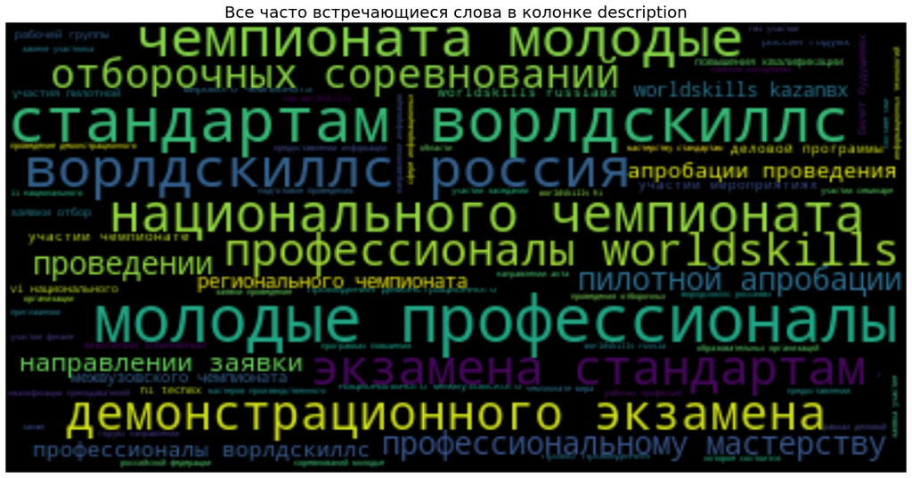

```python
text = df["description"].str.cat()
plt.figure(figsize = (20, 20))
# Create and generate a word cloud image:
wordcloud = WordCloud().generate(text)

# Display the generated image:
plt.imshow(wordcloud, interpolation='bilinear')
plt.axis("off")
plt.title("Все часто встречающиеся слова в колонке description", fontsize = 20)
plt.show()
```

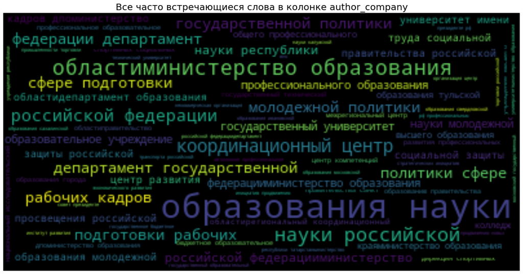

```python
text = df["author_company"].str.cat()
plt.figure(figsize = (20, 20))
# Create and generate a word cloud image:
wordcloud = WordCloud().generate(text)

# Display the generated image:
plt.imshow(wordcloud, interpolation='bilinear')
plt.axis("off")
plt.title("Все часто встречающиеся слова в колонке author_company", fontsize = 20)
plt.show()
```

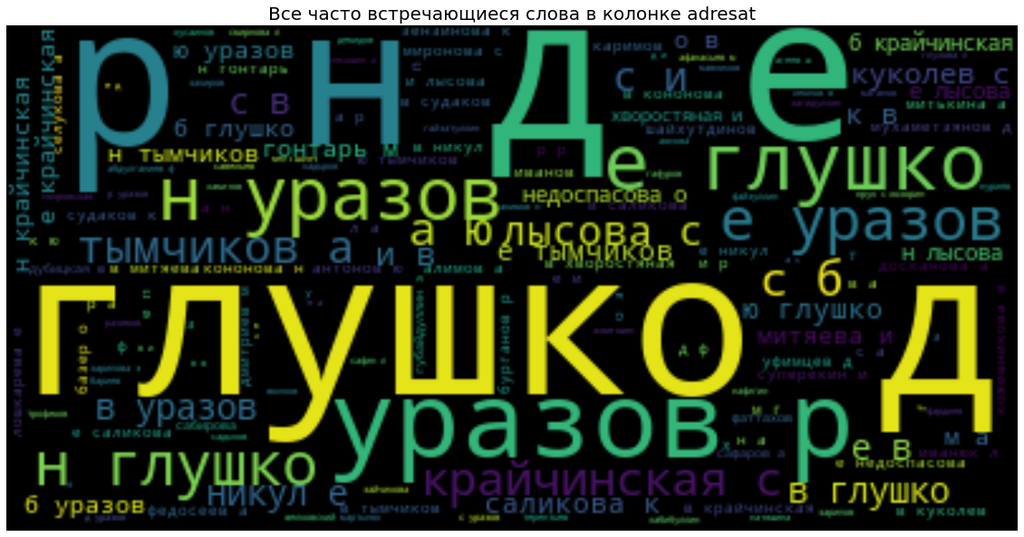

```python
text = df["adresat"].str.cat()
plt.figure(figsize = (20, 20))
# Create and generate a word cloud image:
wordcloud = WordCloud().generate(text)

# Display the generated image:
plt.imshow(wordcloud, interpolation='bilinear')
plt.axis("off")
plt.title("Все часто встречающиеся слова в колонке adresat", fontsize = 20)
plt.show()
```

## Classic plot

Визуализация временных рядов

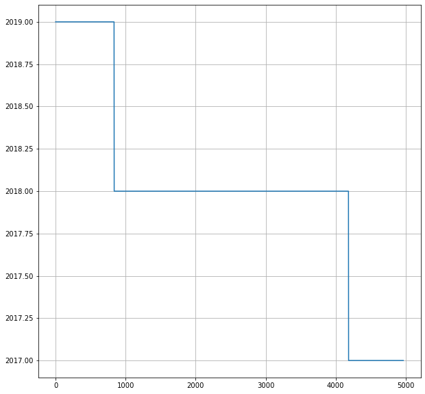

```python
df["year"].plot(figsize = (10, 10), grid = "on")
```

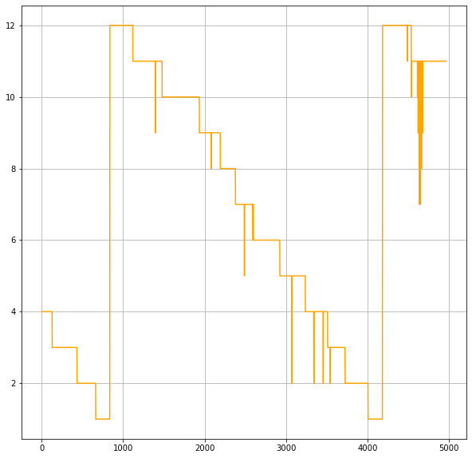

```python
df["month"].plot(figsize = (10, 10), grid = "on", color = "orange")
```

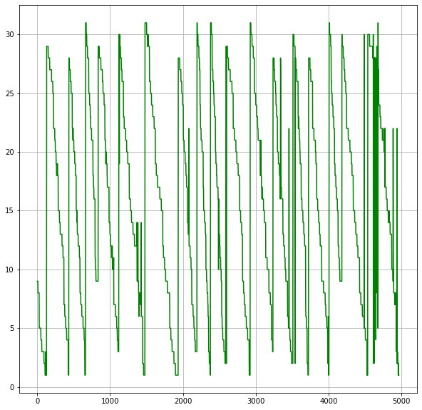

```python
df["day"].plot(figsize = (10, 10), grid = "on", color = "green")
```

# Модуль 2. Классификация документов

```python
from sklearn.ensemble import GradientBoostingClassifier
from sklearn.naive_bayes import GaussianNB
from sklearn.svm import SVC

gbc = GradientBoostingClassifier()
gauss = GaussianNB()
svc = SVC()
```

Далее необходимо выбрать разбиение данных. Учитывая, что данных неособо много, то будем разделять выборку больше в тренировку, чем в тест. Поэтому разделим `90%` на `10%`

## Обучение модели. Используем метод главных компонент для уменьшения размерности

Определяем метод главных компонент

```python
from sklearn.decomposition import PCA
pca = PCA(n_components=500)
pca_feat_x = pca.fit_transform(vect_dict)
```

Отделяем признаки от целевой переменной

```python
X = pca_feat_x
y = df["adresat"].values
```

Разбиваем данные из условия выше

```python
from sklearn.model_selection import train_test_split
X_train, X_test, y_train, y_test = train_test_split(X,y, test_size = 0.1, shuffle = True)
```

### SVC

```python
svc.fit(X_train, y_train)
```

```
SVC()
```

```python
df["adresat"].value_counts()
```

```
глушко д.е.                               1559
уразов р.н.                               1464
крайчинская с.б.                           315
лысова с.и.                                234
тымчиков а.ю.                              229
                                          ...
тунина к.в.                                  1
тымчиков а.ю.\nакимов п.м.\nбазер о.э.       1
уразов р.н.\nпесков д.н.                     1
митяева и.в.\nкрайчинская с.б.               1
мухаметзянов д.ф.\nкрайчинская с.б.          1
Name: adresat, Length: 161, dtype: int64
```

```python
svc.score(X_test, y_test)
```

```
0.7867203219315896
```

```python
svc.score(X_train, y_train)
```

```
0.7774792925901052
```

```python
print(classification_report(y_test, svc.predict(X_test)))
```

[output not shown]

[output cut: 76 more lines]

### Заключение по первичному обучению

Как видим наша модель методом опорных векторов показала неплохой результат на мультиклассовой классификации. Далее нам необходимо провести Feature Engineering, чтобы привести к наилучшему результату

## Feature Engineering

Идея реконструирования признаков в том, чтобы привести классифкацию к классу важности и сделать ее бинарной:

- Для этого создадим функцию которая будет кодировать наиболее важных представителей WS. А именно `уразов р.н.` и `глушко д.е.`- 1, остальные же отправляются сразу в класс - 0.
- Провести обучение на новой целевой переменной `class_v`

Определяем функцию

```python
import warnings
warnings.filterwarnings("ignore")
```

```python
def class_v(x):
    if x == str("уразов р.н."):
        return 1
    elif x == str("глушко д.е."):
        return 1
    else:
        return 0
```

Создаем новую колонку и заполняем пустыми значениями, после чего используем `lambda`

```python
import numpy as np
df["class_v"] = np.nan
df["class_v"] = df["adresat"].apply(lambda x: class_v(x))
```

Определяем новый `X` и `y`

```python
X = pca_feat_x
y = df["class_v"].values
```

Снова разделяем данные

```python
from sklearn.model_selection import train_test_split
X_train, X_test, y_train, y_test = train_test_split(X,y, test_size = 0.1, shuffle = True)
```

Тренируем

```python
svc.fit(X_train, y_train)
```

```
SVC()
```

Тестируем на метриках

```python
from sklearn.metrics import classification_report
print(classification_report(y_test, svc.predict(X_test)))
```

```
              precision    recall  f1-score   support

           0       0.86      0.76      0.81       206
           1       0.84      0.91      0.88       291

    accuracy                           0.85       497
   macro avg       0.85      0.84      0.84       497
weighted avg       0.85      0.85      0.85       497
```